# Final assignment

Experiment 2: Positive instruction Course: Analyzing experimental-psychological data with R (Grüner & Forstinger)

Elisa Grünauer

Lars Keuter

Dominik Pegler

28 Juni 2022

# Experiment 2

## Content

- Research question
- Method
- Results

## Research question

Which validity effects are elicited by the cues in the condition of positive instruction?

## Method

### Participants

20 participants (12 women, 8 men) aged between 18 and 29 years (*M* = 20.95, *SD* = 2.76, *Mdn* = 20) took part in the experiment. No participant was excluded. Since this was only one condition of the experiment, we didn’t want to remove any outliers for the time being. Outlier removal could then be considered and discussed in a second step across all conditions of the experiment.

## Plotting

### Reaction times by participant and condition

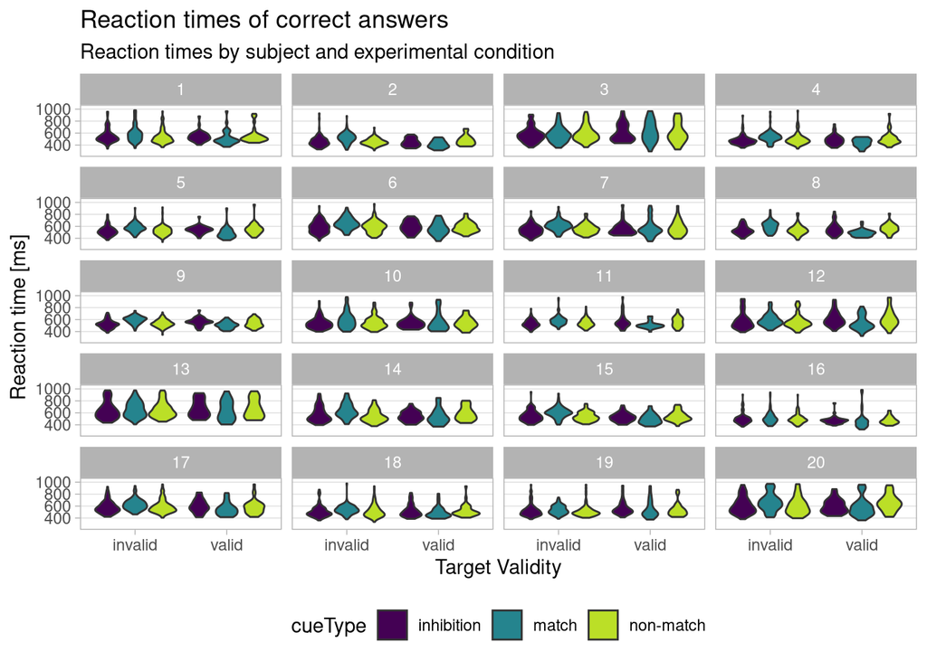

### Mean reaction times and standard errors

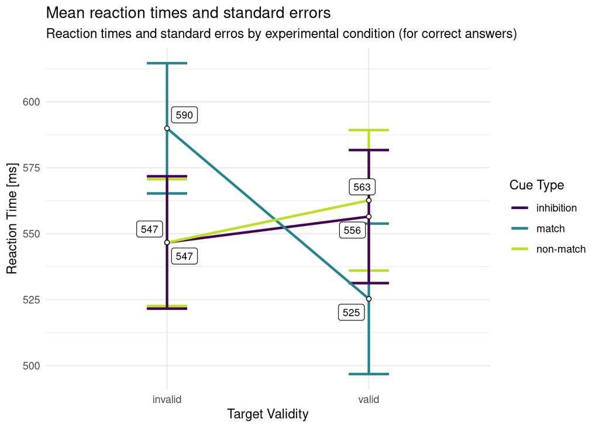

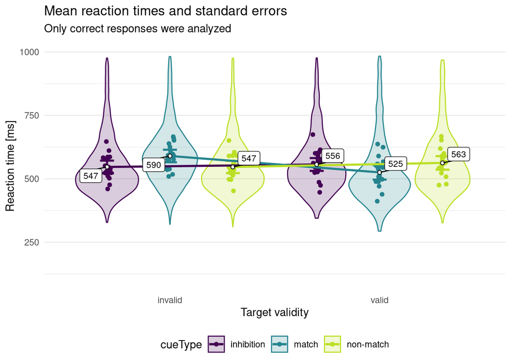

### Validity effect

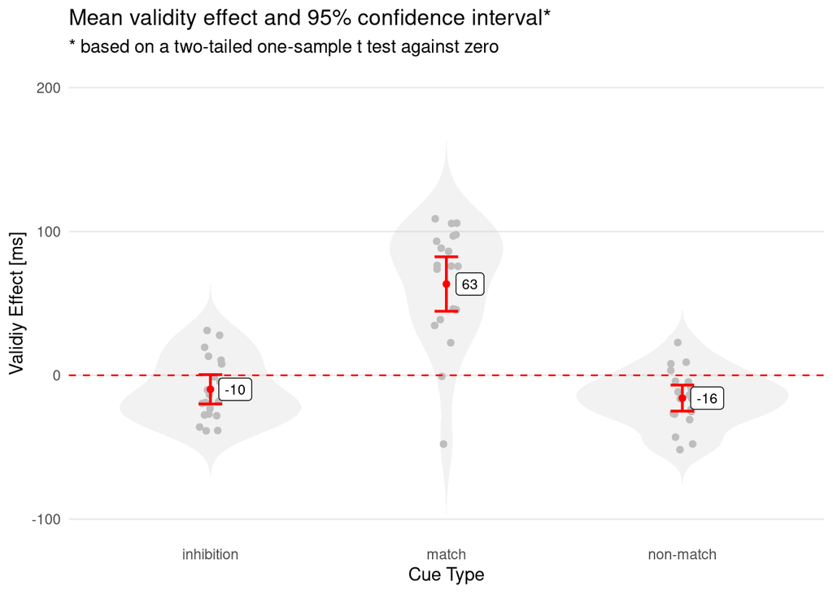

### Number of correct trials

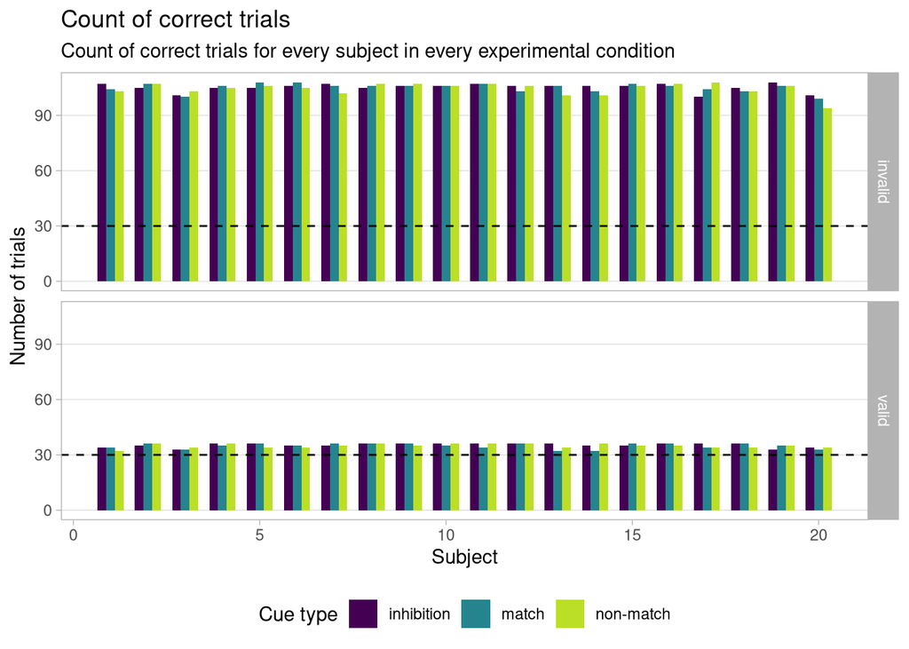

### Reaction Times

We analyzed the reaction time of correct responses using a linear mixed-effect model with the fixed factors target validity and cue type and the per-participant intercept as a random factor. Hierarchical model comparisons showed that the model with the interaction between target validity and cue condition best explained the data. The mean reaction times are shown in Table 1.

Post-hoc test showed that the interaction is driven by significantly slower reaction time in trials with invalid compared to valid matching cues. We found the reversed pattern with non-matching cues, where reaction times were significantly slower in trials with valid compared to invalid cues. Correspondingly, reaction times were significantly faster in matching compared to valid non-matching valid and inhibition cues, see Table 2. The mean reaction times including individual means are plotted in Figure 1.

Table 1: Mean Reaction Times

| Cue Condition | Target Validity | *M* | *SE* | df | Lower CI | Upper CI |
| --- | --- | --- | --- | --- | --- | --- |
| inhibition | invalid | 547 | 2.21 | 6199.29 | 543 | 551 |
| match | invalid | 590 | 2.22 | 6199.29 | 586 | 595 |
| non-match | invalid | 547 | 2.22 | 6199.29 | 543 | 552 |
| inhibition | valid | 557 | 4.14 | 2005.29 | 549 | 565 |
| match | valid | 527 | 4.17 | 2005.29 | 519 | 535 |
| non-match | valid | 563 | 4.17 | 2005.29 | 555 | 571 |

Note: *M*, *SE*, and CIs in ms.

Table 2: Comparisons Between Mean Reaction Times

| Comparisons | cue type / Target Validity | *M* | *SE* | df | *t* statstic | *p* value |
| --- | --- | --- | --- | --- | --- | --- |
| inhibition - match | invalid | -43 | 3.13 | 6199 | -13.81 | < .001 |
| inhibition - (non-match) | invalid | 0 | 3.14 | 6199 | -0.10 | .995 |
| match - (non-match) | invalid | 43 | 3.14 | 6199 | 13.68 | < .001 |
| inhibition - match | valid | 30 | 5.88 | 2005 | 5.10 | < .001 |
| inhibition - (non-match) | valid | -6 | 5.87 | 2005 | -1.09 | .517 |
| match - (non-match) | valid | -36 | 5.89 | 2005 | -6.17 | < .001 |
| invalid - valid | inhibition | -10 | 4.70 | 3238 | -2.07 | .039 |
| invalid - valid | match | 63 | 4.72 | 3223 | 13.45 | < .001 |
| invalid - valid | non-match | -16 | 4.72 | 3233 | -3.35 | .001 |

Note: *M* and *SE* in ms.

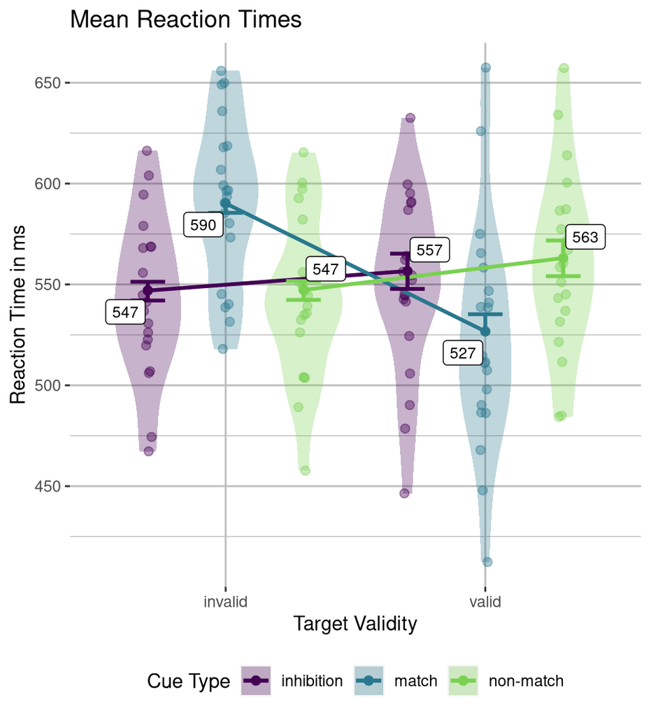

### Validity Effects

Using a two-sided one sample *t* test against zero, we found a statistically significant validity effect for matching cues (*M* = 67 ms, 95% CI [45, 89], *SD* = 46 ms, *t*(19) = 6.49, *p* = .000, *d<sub>unbiased</sub>* = 1.39 [0.81, 2.08]) and a significant negative validity effect for non-matching cues (*M* = -18 ms, [-29, -8], *SD* = 23 ms, *t*(19) = -3.6, *p* = .002, *d<sub>unbiased</sub>* = -0.77, [-1.3, -0.29]). Figure 2 shows the validity effects.

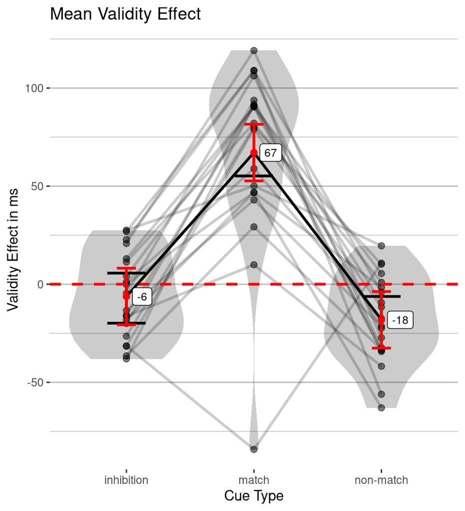

Figure 2: Validity effect for matching and non-matching cues (in red) and for each participant (grey points). The individual validity effects are plotted to show their distribution. The lines connect values of one participants, and the red error bars represent the 95% CI for the one-sample *t* test against zero (red dotted line). In this case, no overlapping of the CI with zero indicates a significant difference. The black error bars represent 95% comparison intervals for the mean comparison. The values have only one error bar since there is only the comparison with the other value. If the comparison intervals do not overlap, the difference is significant. No validity effect was found for the inhibition cues.

### Model diagnostic

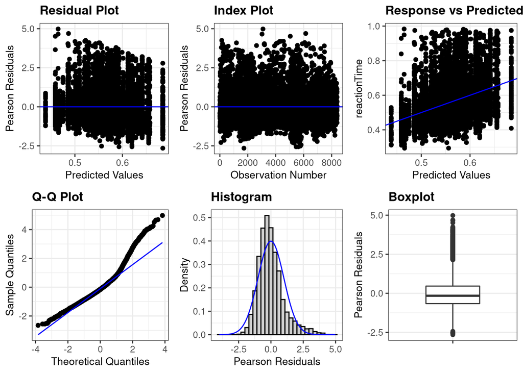

```r
resid_panel(rt.interaction, plots = "all")
```

The model assumptions are met for the following reasons:

**Independence of observations**

This requirement is given by design. Although the available within-subject factors are not independent per subject, this was taken into account by the random effect (`(1 | sbj)`.

**Linear relationship between predictor variables and response variables**

The comparison of the predicted and the actual reaction times shows a linear relationship.

**Consistent variance of the residuals**

The residual plot shows that the variance of the residuals is pretty much the same: the residuals are fairly evenly distributed around the horizontal axis, and no particular pattern can be discerned (although there are some upward deviations, but the model should be sufficiently robust)

**Normal distribution of the residuals**